# Transform Data

```r
library(tidyverse)
library(babynames)
library(nycflights13)

# Toy datasets to use

pollution <- tribble(
       ~city,   ~size, ~amount,
  "New York", "large",      23,
  "New York", "small",      14,
    "London", "large",      22,
    "London", "small",      16,
   "Beijing", "large",      121,
   "Beijing", "small",      56
)

band <- tribble(
   ~name,     ~band,
  "Mick",  "Stones",
  "John", "Beatles",
  "Paul", "Beatles"
)

instrument <- tribble(
    ~name,   ~plays,
   "John", "guitar",
   "Paul",   "bass",
  "Keith", "guitar"
)

instrument2 <- tribble(
    ~artist,   ~plays,
   "John", "guitar",
   "Paul",   "bass",
  "Keith", "guitar"
)

weights = tribble(
  ~name, ~lbs,
  "Stipe", 255,
  "Jan", 205,
  "Israel", 185,
  "Karamu", 170,
  "Khabib", 150
)
```

## babynames

| year | sex | name | n | prop |
| --- | --- | --- | --- | --- |
| 1880 | F | Mary | 7065 | 0.07238359 |
| 1880 | F | Anna | 2604 | 0.02667896 |
| 1880 | F | Emma | 2003 | 0.02052149 |
| 1880 | F | Elizabeth | 1939 | 0.01986579 |
| 1880 | F | Minnie | 1746 | 0.01788843 |
| 1880 | F | Margaret | 1578 | 0.01616720 |
| 1880 | F | Ida | 1472 | 0.01508119 |
| 1880 | F | Alice | 1414 | 0.01448696 |
| 1880 | F | Bertha | 1320 | 0.01352390 |
| 1880 | F | Sarah | 1288 | 0.01319605 |

[output cut: 990 more lines]

## Your Turn 1

Alter the code to select just the `n` column:

```r
str(babynames)
```

```
tibble [1,924,665 x 5] (S3: tbl_df/tbl/data.frame)
 $ year: num [1:1924665] 1880 1880 1880 1880 1880 1880 1880 1880 1880 1880 ...
 $ sex : chr [1:1924665] "F" "F" "F" "F" ...
 $ name: chr [1:1924665] "Mary" "Anna" "Emma" "Elizabeth" ...
 $ n   : int [1:1924665] 7065 2604 2003 1939 1746 1578 1472 1414 1320 1288 ...
 $ prop: num [1:1924665] 0.0724 0.0267 0.0205 0.0199 0.0179 ...
```

## Quiz

Which of these is NOT a way to select the `name` and `n` columns together?

| name | n |
| --- | --- |
| Mary | 7065 |
| Anna | 2604 |
| Emma | 2003 |
| Elizabeth | 1939 |
| Minnie | 1746 |
| Margaret | 1578 |
| Ida | 1472 |
| Alice | 1414 |
| Bertha | 1320 |
| Sarah | 1288 |

[output cut: 990 more lines]

```r
select(babynames, -c(year, sex, prop))

select(babynames, name:n)
```

| name | n |
| --- | --- |
| Mary | 7065 |
| Anna | 2604 |
| Emma | 2003 |
| Elizabeth | 1939 |
| Minnie | 1746 |
| Margaret | 1578 |
| Ida | 1472 |
| Alice | 1414 |
| Bertha | 1320 |
| Sarah | 1288 |

[output cut: 990 more lines]

```r
select(babynames, starts_with("n"))
```

| name | n |
| --- | --- |
| Mary | 7065 |
| Anna | 2604 |
| Emma | 2003 |
| Elizabeth | 1939 |
| Minnie | 1746 |
| Margaret | 1578 |
| Ida | 1472 |
| Alice | 1414 |
| Bertha | 1320 |
| Sarah | 1288 |

[output cut: 990 more lines]

```r
select(babynames, ends_with("n"))
```

| n |
| --- |
| 7065 |
| 2604 |
| 2003 |
| 1939 |
| 1746 |
| 1578 |
| 1472 |
| 1414 |
| 1320 |
| 1288 |

[output cut: 990 more lines]

## Your Turn 2

Show:

- All of the names where prop is greater than or equal to 0.08
- All of the children named “Sea”
- All of the names that have a missing value for `n`

| year | sex | name | n | prop |
| --- | --- | --- | --- | --- |
| 1880 | M | John | 9655 | 0.08154561 |
| 1880 | M | William | 9532 | 0.08050676 |
| 1881 | M | John | 8769 | 0.08098299 |

## Your Turn 3

Use Boolean operators to alter the code below to return only the rows that contain:

- Girls named Sea
- Names that were used by exactly 5 or 6 children in 1880
- Names that are one of Acura, Lexus, or Yugo

| year | sex | name | n | prop |
| --- | --- | --- | --- | --- |
| 1982 | F | Sea | 5 | 2.76e-06 |
| 1998 | F | Sea | 5 | 2.58e-06 |

```r
filter(babynames, sex == "F", name == "Sea")

filter(babynames, year == 1880, n %in% c(5, 6) )
```

| year | sex | name | n | prop |
| --- | --- | --- | --- | --- |
| 1880 | F | Abby | 6 | 6.147e-05 |
| 1880 | F | Aileen | 6 | 6.147e-05 |
| 1880 | F | Alba | 6 | 6.147e-05 |
| 1880 | F | Alda | 6 | 6.147e-05 |
| 1880 | F | Alla | 6 | 6.147e-05 |
| 1880 | F | Alverta | 6 | 6.147e-05 |
| 1880 | F | Ara | 6 | 6.147e-05 |
| 1880 | F | Ardelia | 6 | 6.147e-05 |
| 1880 | F | Ardella | 6 | 6.147e-05 |
| 1880 | F | Arrie | 6 | 6.147e-05 |

[output cut: 445 more lines]

```r
filter(babynames, name %in% c( "Acura", "Lexus", "Yugo") )
```

| year | sex | name | n | prop |
| --- | --- | --- | --- | --- |
| 1990 | F | Lexus | 36 | 0.00001753 |
| 1990 | M | Lexus | 12 | 0.00000558 |
| 1991 | F | Lexus | 102 | 0.00005017 |
| 1991 | M | Lexus | 16 | 0.00000755 |
| 1992 | F | Lexus | 193 | 0.00009629 |
| 1992 | M | Lexus | 25 | 0.00001191 |
| 1993 | F | Lexus | 285 | 0.00014458 |
| 1993 | M | Lexus | 30 | 0.00001453 |
| 1994 | F | Lexus | 381 | 0.00019548 |
| 1994 | F | Acura | 6 | 0.00000308 |

[output cut: 47 more lines]

## Your Turn 4

Arrange babynames by `n`. Add `prop` as a second (tie breaking) variable to arrange on. Can you tell what the smallest value of `n` is?

| year | sex | name | n | prop |
| --- | --- | --- | --- | --- |
| 2007 | M | Aaban | 5 | 2.26e-06 |
| 2007 | M | Aareon | 5 | 2.26e-06 |
| 2007 | M | Aaris | 5 | 2.26e-06 |
| 2007 | M | Abd | 5 | 2.26e-06 |
| 2007 | M | Abdulazeez | 5 | 2.26e-06 |
| 2007 | M | Abdulhadi | 5 | 2.26e-06 |
| 2007 | M | Abdulhamid | 5 | 2.26e-06 |
| 2007 | M | Abdulkadir | 5 | 2.26e-06 |
| 2007 | M | Abdulraheem | 5 | 2.26e-06 |
| 2007 | M | Abdulrahim | 5 | 2.26e-06 |

[output cut: 990 more lines]

## Your Turn 5

Use `desc()` to find the names with the highest prop. Then, use `desc()` to find the names with the highest n.

| year | sex | name | n | prop |
| --- | --- | --- | --- | --- |
| 1947 | F | Linda | 99686 | 0.05483812 |
| 1948 | F | Linda | 96209 | 0.05521079 |
| 1947 | M | James | 94756 | 0.05101589 |
| 1957 | M | Michael | 92695 | 0.04237565 |
| 1947 | M | Robert | 91642 | 0.04933934 |
| 1949 | F | Linda | 91016 | 0.05184643 |
| 1956 | M | Michael | 90620 | 0.04225546 |
| 1958 | M | Michael | 90520 | 0.04204290 |
| 1948 | M | James | 88588 | 0.04969695 |
| 1954 | M | Michael | 88514 | 0.04279319 |

[output cut: 990 more lines]

```r
arrange(babynames, desc(n), prop)

arrange(babynames, desc(prop))
```

| year | sex | name | n | prop |
| --- | --- | --- | --- | --- |
| 1880 | M | John | 9655 | 0.08154561 |
| 1881 | M | John | 8769 | 0.08098299 |
| 1880 | M | William | 9532 | 0.08050676 |
| 1883 | M | John | 8894 | 0.07907394 |
| 1881 | M | William | 8524 | 0.07872038 |
| 1882 | M | John | 9557 | 0.07831617 |
| 1884 | M | John | 9388 | 0.07648813 |
| 1882 | M | William | 9298 | 0.07619375 |
| 1886 | M | John | 9026 | 0.07582262 |
| 1885 | M | John | 8756 | 0.07551856 |

[output cut: 990 more lines]

```r
NA
```

## Your Turn 6

Use `%>%` to write a sequence of functions that:

1. Filter babynames to just the girls that were born in 2015
2. Select the `name` and `n` columns
3. Arrange the results so that the most popular names are near the top.

| name | n |
| --- | --- |
| Emma | 20435 |
| Olivia | 19669 |
| Sophia | 17402 |
| Ava | 16361 |
| Isabella | 15594 |
| Mia | 14892 |
| Abigail | 12390 |
| Emily | 11780 |
| Charlotte | 11390 |
| Harper | 10291 |

[output cut: 990 more lines]

## Exam

1. Trim `babynames` to just the rows that contain your `name` and your `sex`
2. Trim the result to just the columns that will appear in your graph (not strictly necessary, but useful practice)
3. Plot the results as a line graph with `year` on the x axis and `prop` on the y axis

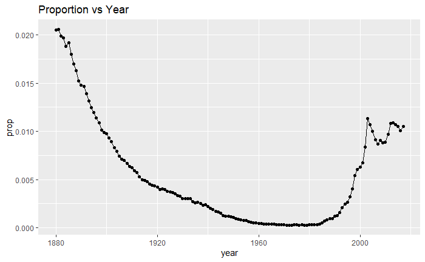

## Your Turn 7

Use summarise() to compute three statistics about the data:

1. The first (minimum) year in the dataset
2. The last (maximum) year in the dataset
3. The total number of children represented in the data

| min_year | max_year | total |
| --- | --- | --- |
| 1880 | 2017 | 348120517 |

## Your Turn 8

Extract the rows where `name == "Khaleesi"`. Then use `summarise()` and a summary functions to find:

1. The total number of children named Khaleesi
2. The first year Khaleesi appeared in the data

| first_year | total |
| --- | --- |
| 2011 | 1964 |

## Your Turn 9

Use `group_by()`, `summarise()`, and `arrange()` to display the ten most popular names. Compute popularity as the total number of children of a single gender given a name.

```r
babynames %>%
  group_by( sex ) %>%
  summarise( total = sum(n) )
```

| sex | total |
| --- | --- |
| F | 172371079 |
| M | 175749438 |

## Your Turn 10

Use grouping to calculate and then plot the number of children born each year over time.

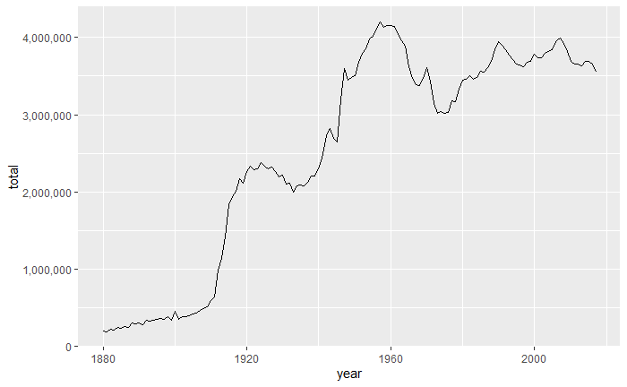

```r
library( scales )
babynames %>%
  group_by( year ) %>%
  summarise( total = sum(n) ) %>%
  ggplot( aes( x = year, y = total)) + geom_line() +
  scale_y_continuous( label = comma)
```

# Your turn 11

Below is a list of professional martial artists and their weight in pounds. Create a new column, kg, that contains their weight in kilograms.

Note: Multiply each element of the `lbs` column by 0.45 to get the number of kilograms..

| name | lbs | kg |
| --- | --- | --- |
| Stipe | 255 | 114.75 |
| Jan | 205 | 92.25 |
| Israel | 185 | 83.25 |
| Karamu | 170 | 76.50 |
| Khabib | 150 | 67.50 |

## Your Turn 12

What airline had the most flights?

Solve this problem in two ways. 1. First fill in the blanks below to first the question for the “carrier” column 2. Then add a “left_join” to get the airline name

```r
flights %>%
  group_by( carrier ) %>%
  summarize( nflight = n() ) %>%
  arrange( desc(nflight) ) %>%
  left_join( airlines, by = "carrier" )
```

| carrier | nflight | name |
| --- | --- | --- |
| UA | 58665 | United Air Lines Inc. |
| B6 | 54635 | JetBlue Airways |
| EV | 54173 | ExpressJet Airlines Inc. |
| DL | 48110 | Delta Air Lines Inc. |
| AA | 32729 | American Airlines Inc. |
| MQ | 26397 | Envoy Air |
| US | 20536 | US Airways Inc. |
| 9E | 18460 | Endeavor Air Inc. |
| WN | 12275 | Southwest Airlines Co. |
| VX | 5162 | Virgin America |

[output cut: 6 more lines]

## Your Turn 13

Which airlines had the largest average arrival delays?

“drop_na” will drop rows that have a missing arrival delay.

```r
flights %>%
  drop_na( arr_delay ) %>%
  group_by( carrier ) %>%
  summarize( AveArrivalDelay = mean(arr_delay) ) %>%
  arrange( desc(AveArrivalDelay) ) %>%
  left_join( airlines, by = "carrier" )
```

| carrier | AveArrivalDelay | name |
| --- | --- | --- |
| F9 | 21.9207048 | Frontier Airlines Inc. |
| FL | 20.1159055 | AirTran Airways Corporation |
| EV | 15.7964311 | ExpressJet Airlines Inc. |
| YV | 15.5569853 | Mesa Airlines Inc. |
| OO | 11.9310345 | SkyWest Airlines Inc. |
| MQ | 10.7747334 | Envoy Air |
| WN | 9.6491199 | Southwest Airlines Co. |
| B6 | 9.4579733 | JetBlue Airways |
| 9E | 7.3796692 | Endeavor Air Inc. |
| UA | 3.5580111 | United Air Lines Inc. |

[output cut: 6 more lines]

## Your Turn 14

Use `flights` and `airports` to compute the average arr_delay by destination airport. Store the variable as `mean_arr_delay`.

Order by `mean_arr_delay`, descending.

Select just 3 columns from the output: dest, name and mean_arr_delay.

```r
flights %>%
  group_by( dest ) %>%
  summarize( mean_arr_delay = mean(arr_delay, na.rm = TRUE) ) %>%
  arrange( desc(mean_arr_delay) ) %>%
  left_join( airports, by = c("dest" = "faa") ) %>%
  select( dest, name, mean_arr_delay )
```

| dest | name | mean_arr_delay |
| --- | --- | --- |
| CAE | Columbia Metropolitan | 41.76415094 |
| TUL | Tulsa Intl | 33.65986395 |
| OKC | Will Rogers World | 30.61904762 |
| JAC | Jackson Hole Airport | 28.09523810 |
| TYS | Mc Ghee Tyson | 24.06920415 |
| MSN | Dane Co Rgnl Truax Fld | 20.19604317 |
| RIC | Richmond Intl | 20.11125320 |
| CAK | Akron Canton Regional Airport | 19.69833729 |
| DSM | Des Moines Intl | 19.00573614 |
| GRR | Gerald R Ford Intl | 18.18956044 |

[output cut: 95 more lines]

# Take aways

- Extract variables with `select()`
- Extract cases with `filter()`
- Arrange cases, with `arrange()`
- Make tables of summaries with `summarise()`
- Make new variables, with `mutate()`
- Do groupwise operations with `group_by()`
- Connect operations with `%>%`
- Use `left_join()`, `right_join()`, `full_join()`, or `inner_join()` to join datasets